# Quizz 9: Exponential

### Question 5

What is the value of $b$?

Prior mean is $1/30$ and $a = 1$, then $b=30$

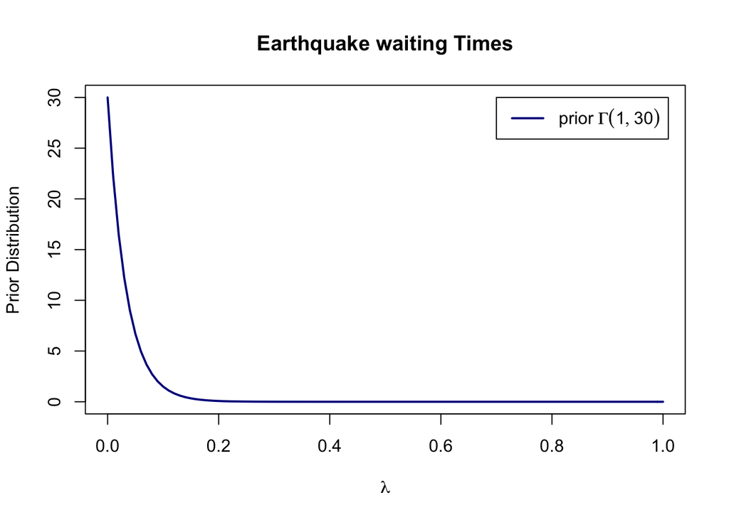

```r
a = 1
b = 30
lambda = seq(0, 1, .01)
curve(dgamma(x, shape = a, rate = b), lty=1, lwd=2, col='darkblue',
      xlab = expression(lambda), ylab = "Prior Distribution",
      main = "Earthquake waiting Times")

legend_labels = c(expression(prior ~ Gamma(1, 30)))

legend(0.7, 30, legend = legend_labels, col=c("darkblue"), lty=c(1, 2), lwd=2)
```

Given a r.v. $X\sim Exp(X)$:

- $E[X] = 1/\lambda$
- $Var(X) = 1/\lambda^2$

In this example for prior $lambda$, $E[\lambda] = 0.033$ and $Var(\lambda) = 0.001$

[figure not shown]

```r
X = seq(0, 200, 1)
plot(X,
     dexp(X, rate = 1/30),
     type='l', lty=1, lwd=2, col="cyan",
     xlab = expression(Y ~ (minutes)), ylab = "Likelihood",
     main = expression(Likelihood ~ f(Y ~"|"~ lambda ~ "= 1/30"))
     )
legend(155, 0.033, legend = "Exp(1/30)", col = "cyan", lty=1)
```

### Question 6

The significant earthquakes of magnitude 4.0+ in the state of California during 2015 occurred on the following dates http://earthquake.usgs.gov/earthquakes/browse/significant.php?year=2015:

January 4, January 20, January 28, May 22, July 21, July 25, August 17, September 16, December 30.

Recall that we are modeling the waiting times between earthquakes in days. Which of the following is our data vector? 1 point

1. **y = (16, 8, 114, 60, 4, 23, 30, 105)**
2. y = (0, 0, 4, 2, 0, 1, 1, 3)
3. y = (3, 16, 8, 114, 60, 4, 23, 30, 105)
4. y = (3, 16, 8, 114, 60, 4, 23, 30, 105, 1)

```r
Y = c(16, 8, 114, 60, 4, 23, 30, 105)
Y
```

```
## [1]  16   8 114  60   4  23  30 105
```

**Note**: We are modeling the waiting times between earthquakes in days. There are eight intervals between the first and last event. We are excluding four days of the year in which no events were observed. A more comprehensive model (e.g., censoring methods) would account for the fact that there were no major earthquakes Jan. 1 to Jan. 4 and Dec. 30 to Dec. 31. This is beyond the scope of this tutorial. [[Source](https://rpubs.com/army_aviator/370794)]

### Question 7

Having observed data $Y = \{y_1, \cdots, y_n \}$, for **Exponential likelihood** and **Gamma prior** the posterior is:

$\lambda \mid Y \sim Gamma(\alpha + n,~ \beta + \sum{y_i} )$

What is the value of $\alpha$?

```r
a.post = a + length(Y)
a.post
```

```
## [1] 9
```

### Question 8

What is the value of $\beta$?

```r
b.post = b + sum(Y)
b.post
```

```
## [1] 390
```

### Question 9

Use R or Excel to calculate the upper end of the 95% equal-tailed credible interval for $\lambda$, the rate of major earthquakes in events per day. Round your answer to two decimal places.

```r
qgamma(p =.975, shape=a.post, rate=b.post)
```

```
## [1] 0.04041843
```

[figure not shown]

```r
lambda = seq(0, 01, 0.01)
plot(lambda, dgamma(lambda, shape = a.post, rate = b.post), type = "l", lty=2, lwd=2, col='darkorange',
      xlab = expression(lambda), ylab = "Distribution",
      main = "Earthquake Waiting Times")

lines(lambda, dgamma(lambda, shape = a, rate = b), lty=1, lwd=2, col='darkblue')

legend_labels = c(expression(post. ~ Gamma(9, 390)),
                  expression(prior ~ Gamma(1, 30)))

legend(0.68, 55, legend = legend_labels, col=c("darkorange", "darkblue"), lty=c(1, 2), lwd=2)
```

### Question 10

The posterior predictive density for a new waiting time $y^*$ in days is:

$f(y^* \mid \mathbf{y} ) = \int f(y^* \mid \lambda) \cdot f(\lambda \mid \mathbf{y}) d\lambda = \frac{ \beta^\alpha \Gamma(\alpha + 1) }{ (\beta + y^*)^{\alpha + 1} \Gamma(\alpha) } I_{\{y^* \ge 0 \}} = \frac{ \beta^\alpha \alpha}{ (\beta + y^*)^{\alpha + 1}} I_{\{y^* \ge 0 \}}$

where $f(\lambda \mid \mathbf{y})$ is the $\text{Gamma}(\alpha, \beta)$ posterior found earlier. Use R or Excel to evaluate this posterior predictive PDF.

Which of the following graphs shows the posterior predictive distribution for $y^*$

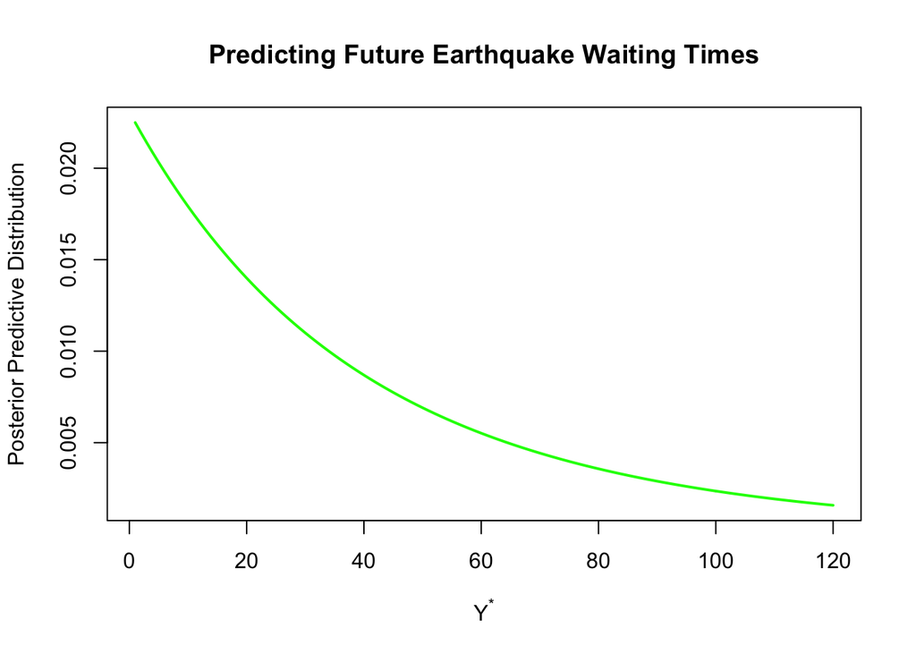

```r
post.pred.dist <- function(x, a, b){
  y = ((b^a) * a) / ((b + x)^(a+1))
  return(y)
}

x = seq(1, 120)
plot(x, post.pred.dist(x, a.post, b.post), type='l', lty=1, lwd=2, col='green',
     xlab = expression(Y^"*"),  ylab = "Posterior Predictive Distribution",
     main = "Predicting Future Earthquake Waiting Times")
```

Back to Index